# CREscendo Tutorial: Analysis of 10X Genomics human PBMC Single-Cell Multiome Data

# Introduction

scATAC-seq captures fragments through Tn5 tagmentation, which allows for precise analysis of regulatory elements by examining the Tn5 cleavage sites. Unfortunately, the detailed base-resolution information is often condensed and simplified in current peak-based scATAC-seq analyses. The peak calling software, such as Cellranger, generates a broad range of peak sizes, while MACS2 can identify significantly smaller peaks. However, even these smaller peaks generally exceed the size of a single cis-regulatory element (CRE) as annotated by ENCODE. To address this issue, we introduce the CREscendo framework, which is designed to analyze differential usage of CREs by examining differences in Tn5 cleavage frequencies across cell types. This approach helps to recover regulatory signals that peak-based analyses often overlook.

Specifically, CREscendo segments each peak into designated regions such as CRE1, CRE2, and so forth, along with non-CRE areas. For each peak, a frequency vector is constructed, and a chi-square test is conducted to detect statistically significant differences in cleavage frequencies across different cell types. The resulting p-values are adjusted for multiple testing, and the significant CREs are identified. The CREscendo framework is implemented as an R package, available on GitHub.

# Installation

To install the `CREscendo` package, you can use the code.

```r
devtools::install_github("ChenMengjie/CREscendo")
```

Then load the following libraries used in this tutorial:

```r
library(Signac)
library(Seurat)
library(EnsDb.Hsapiens.v75)
library(TxDb.Hsapiens.UCSC.hg38.knownGene)
library(CREscendo)
library(ggrepel)
library(tictoc)
```

# Dataset: PBMC multiome from a Healthy Donor - Granulocytes Removed Through Cell Sorting (10k)

We downloaded the PBMC multiome dataset, which includes peak files and fragment files, from [10x Genomics](https://www.10xgenomics.com/datasets/pbmc-from-a-healthy-donor-granulocytes-removed-through-cell-sorting-10-k-1-standard-2-0-0). The multiome platform produces data that includes both ATAC and RNA profiles from the same cells. Each cell’s data is linked by a unique cell barcode. The dataset is estimated to contain 11,898 cells. We conducted quality control using Signac as showed in their [tutorial](https://stuartlab.org/signac/articles/pbmc_multiomic) and the object is saved as `pbmc_10X_multiome.rds`, downloadable from this link.

```r
pbmc <- readRDS("/path/to/pbmc_10X_multiome.rds")
pbmc
peaks.gr <- granges(pbmc@assays$peaks)
peaks.gr <- peaks.gr[grep("chr", seqnames(peaks.gr))]
peaks.gr
```

For the annotation of cis-regulatory elements (CREs), we utilized resources from the ENCODE Encyclopedia, specifically the Registry of cCREs Version 3 from [SCREEN](https://downloads.wenglab.org/V3/GRCh38-cCREs.bed). This resource details 1,063,878 candidate CREs identified by segregating signals across all biospecimen sourced from 1,518 cell types. These CREs are categorized further into candidate promoters, candidate proximal enhancers, candidate distal enhancers, and are also annotated based on their CTCF binding status.

We have implemented functions to load the CREs from the ENCODE SCREEN V3 directly.

```r
CRE_gr <- CREscendo:::load_CRE_annotations(genome = "hg38")
CRE_gr
```

```
## GRanges object with 1063878 ranges and 3 metadata columns:
##             seqnames            ranges strand |          ID1          ID2
##                <Rle>         <IRanges>  <Rle> |  <character>  <character>
##         [1]     chr1     104896-105048      + | EH38D4327509 EH38E2776520
##         [2]     chr1     138866-139134      + | EH38D4327520 EH38E2776521
##         [3]     chr1     181289-181639      + | EH38D4327525 EH38E2776524
##         [4]     chr1     267925-268171      + | EH38D4327544 EH38E2776528
##         [5]     chr1     586036-586264      + | EH38D4327554 EH38E2776532
##         ...      ...               ...    ... .          ...          ...
##   [1063874]     chrY 21252996-21253278      + | EH38D6144481 EH38E3951203
##   [1063875]     chrY 21598449-21598656      + | EH38D6144550 EH38E3951229
##   [1063876]     chrY 21839503-21839853      + | EH38D6144588 EH38E3951242
##   [1063877]     chrY 26352857-26353207      + | EH38D4327371 EH38E3951251
##   [1063878]     chrY 26353315-26353520      + | EH38D4327372 EH38E3951252
##                               type
##                        <character>
##         [1]   CTCF-only,CTCF-bound
##         [2]        pELS,CTCF-bound
##         [3] DNase-H3K4me3,CTCF-b..
##         [4]   CTCF-only,CTCF-bound
##         [5]   CTCF-only,CTCF-bound
##         ...                    ...
##   [1063874]                   dELS
##   [1063875]   CTCF-only,CTCF-bound
##   [1063876]                   dELS
##   [1063877]                   pELS
##   [1063878]                   pELS
##   -------
##   seqinfo: 24 sequences from an unspecified genome; no seqlengths
```

You can also prepare your own annotations file from other sources like the following:

```r
anno_CREs <- read.delim("/path/to/GRCh38-cCREs.bed", header = F)
CRE_gr <- GRanges(ranges=IRanges(start=anno_CREs[, 2], end=anno_CREs[, 3]),
                  seqnames=anno_CREs[, 1],
                  strand=rep("+", nrow(anno_CREs)), ID1 = anno_CREs[, 4], ID2 = anno_CREs[, 5],
                  type = anno_CREs[, 6])
CRE_gr
```

We can compare the peak sizes and the CRE sizes.

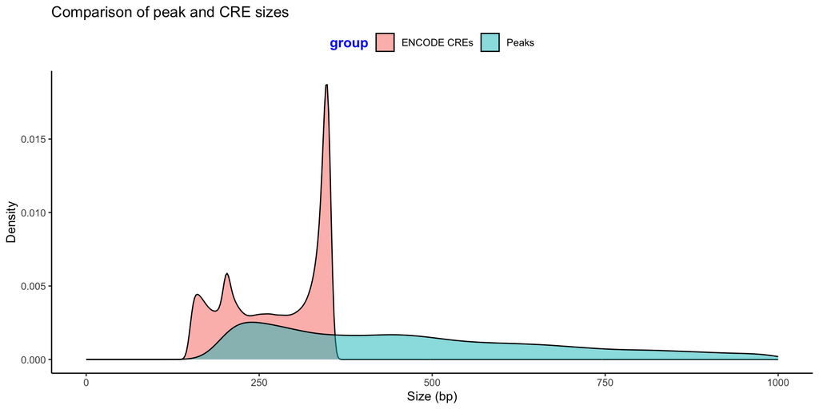

```r
peak_width <- width(peaks.gr)
CRE_width <- width(CRE_gr)
data <- data.frame(
  values = c(CRE_width, peak_width),
  group = c(rep("ENCODE CREs", length(CRE_width)),
            rep("Peaks", length(peak_width)))
)

####
pg <- ggplot(data, aes(x = values, fill = group)) +
  geom_density(alpha = 0.5, adjust = 1.2) +
  theme_classic() + xlim(0, 1000)+
  labs(title = "Comparison of peak and CRE sizes", x = "Size (bp)", y = "Density") +
  theme(legend.title = element_text(color = "blue", size = 12, face = "bold"),
        legend.position = "top")
pg
```

## Creating a CREscendo Test Data Object

In the CREscendo test, Tn5 cleavage frequencies are used as the input. However, this information is not readily available in the peak file alone. To obtain Tn5 cleavage data, we need to screen the fragment files. Given that these fragment files are typically quite large, we opt for the Tabix-indexed file format. Tabix files are compressed and indexed, allowing for efficient data retrieval.

The `PrepareCREscendoObject` function serves as our tool for constructing a CREscendo object. This involves several steps:

1. **Processing and annotating Genomic Peaks**: Initially, we process genomic peaks, which are typically stored in a GenomicRanges object (`peaks_gr`).
2. **Associating Peaks with CREs**: We associate these peaks with cis-regulatory elements (CREs), thereby establishing their regulatory context.
3. **Compiling Cleavage Site Counts**: The core aspect of the process involves compiling counts of cleavage sites. This requires accessing the Tabix-indexed file (`tabix_file`) containing relevant fragment data.

The `PrepareCREscendoObject` function expects the following inputs:

- `peaks_gr`: GenomicRanges object containing genomic peak locations.
- `tabix_file`: Path to a Tabix-indexed file containing fragments relevant to the peaks.
- `cell_annotation`: Data frame containing cell annotations with columns for cell name and cell type.
- `celltype_list` (Optional): A vector of cell types to include in the analysis. If NULL, all unique cell types from `cell_annotation` will be used.
- `CRE_gr`: GenomicRanges object for cis-regulatory elements.
- `tssRegion`: Numeric vector of length 2 specifying the region around transcription start sites to consider for annotation (defaults to c(-1000, 1000)).
- `TxDb`: A TxDb object containing transcript annotations.
- `annoDb`: Character string, the Bioconductor annotation package for organism-specific data. Default is “org.Hs.eg.db” for human.
- `multiCREs`: Logical value indicating whether to include peaks with multiple CREs (TRUE) or all peaks (FALSE). Default is TRUE.

This function streamlines the process, allowing for efficient preparation and construction of the necessary data object for the CREscendo test.

```r
load("/path/to/cell_annotation_PBMC_multiome.RData")
head(cell_annotation)
```

You can also prepare the data frame as the following example

```r
cells <- colnames(x = pbmc@assays$peaks)
cell_type_list <- c("CD14 Mono", "CD8 Naive", "CD4 TCM", "CD4 Naive", "CD16 Mono", "NK")
cell_annotation <- data.frame(celltype = pbmc@active.ident[pbmc@active.ident%in%cell_type_list],
                              cellname = cells[pbmc@active.ident%in%cell_type_list])
head(cell_annotation)
```

```
##                     celltype           cellname
## AAACAGCCAAGGAATC-1 CD4 Naive AAACAGCCAAGGAATC-1
## AAACAGCCAATCCCTT-1   CD4 TCM AAACAGCCAATCCCTT-1
## AAACAGCCAATGCGCT-1 CD4 Naive AAACAGCCAATGCGCT-1
## AAACAGCCACACTAAT-1 CD8 Naive AAACAGCCACACTAAT-1
## AAACAGCCACCAACCG-1 CD8 Naive AAACAGCCACCAACCG-1
## AAACAGCCAGGATAAC-1 CD4 Naive AAACAGCCAGGATAAC-1
```

The fragment and its index files were downloaded from [10x Genomics](https://www.10xgenomics.com/datasets/pbmc-from-a-healthy-donor-granulocytes-removed-through-cell-sorting-10-k-1-standard-2-0-0)

```r
tbx.path <- "/path/to/pbmc_granulocyte_sorted_10k_atac_fragments.tsv.gz"
index.path <- "/path/to/pbmc_granulocyte_sorted_10k_atac_fragments.tsv.gz.tbi"

tabix.file <- TabixFile(
  file = tbx.path,
  index = index.path
)
open(con = tabix.file)

cell_type_list <- c("CD14 Mono", "CD8 Naive", "CD4 TCM", "CD4 Naive", "CD16 Mono", "NK")

pbmc_CREscendo <- PrepareCREscendoObject(peaks.gr, tabix.file, cell_annotation, cell_type_list,
      CRE_gr, tssRegion=c(-1000, 1000), TxDb = TxDb.Hsapiens.UCSC.hg38.knownGene, annoDb="org.Hs.eg.db")
```

```
## >> preparing features information...      2024-12-18 13:00:32
## >> identifying nearest features...        2024-12-18 13:00:34
## >> calculating distance from peak to TSS...   2024-12-18 13:00:36
## >> assigning genomic annotation...        2024-12-18 13:00:36
## >> adding gene annotation...          2024-12-18 13:01:08
## >> assigning chromosome lengths           2024-12-18 13:01:08
## >> done...                    2024-12-18 13:01:08
##
```

```
## 1480.25 sec elapsed
```

Tn5 cleavage sites are identified by using the start and end sites of each segment from fragment files. We annotate each peak using ENCODE-defined CREs. For peaks with k overlapping CREs, we divide the peak into k+1 segments (cre1, cre2, …, crek) plus an additional segment for base pairs within the peak not covered by any CREs. For each cell type, we construct a frequency vector that represents the number of cleavage sites falling within each segment. The final CREscendo object contains annotated peaks, CRE associations, and cleavage event counts for further analysis.

## Testing CRE Association with specified cell types within a CREscendo Object

The main function `CREtest()` performs chi-squared tests on CREs associated with peaks within a CREscendo object. It evaluates differential CRE activities between two groups of cells.

The required input includes: - `x`: A CREscendo object containing the necessary datasets for CRE analysis. - `celltypes`: One or two cell types. Must be cell types included in the CREscendo object. If one cell type is specified, the comparison will be made between the specified cell type and all other cell types. If two cell types are specified, the comparison will be made between the two specified cell types.

For each peak, we perform a chi-square test with degrees of freedom equal to k (k is the number of overlapping CREs). In the chi-square tests for comparison, with two cell types A and B, we conduct the test first using A as the reference population, and then repeat using B. The final p-value is determined as the maximum (less significant) from these two tests. After generating test statistics for all peaks, we apply false discovery rate (FDR) adjustments to correct for multiple comparisons. We further quantified the contribution of CRE by breaking down the overall chi-square statistic into partial chi-square statistic from each CRE.

As an exmaple, we performed the CREscendo test between CD14 Mono and CD8 Naive cells in PBMC multiome dataset.

```r
tic()
comparison1 <- CREtest(pbmc_CREscendo, celltypes = c("CD14 Mono", "CD8 Naive"))
toc()
```

```
## 742.748 sec elapsed
```

```r
comparison1_summary <- Summarize(comparison1)
head(comparison1_summary)
```

```
##                          chisq_stat fdr max_contribution max_refID   max_dif
## chr1-207335620-207337449   7018.530   0         71.71392         1 0.9271002
## chr7-99379186-99381368     6821.328   0         89.44761         1 0.8709527
## chr22-37229277-37231786    5192.457   0         93.10615         1 0.8887387
## chr20-324079-327474        5179.798   0         83.40310         1 0.8194042
## chr15-64893422-64896017    5025.699   0         87.22747         1 0.8438862
## chr12-561811-564197        4959.921   0         69.25172         1 0.9286845
##                            abs_dif  n_1  n_2 df1
## chr1-207335620-207337449 0.6289844 2774 2123   5
## chr7-99379186-99381368   0.5525971 4006 1636   8
## chr22-37229277-37231786  0.2871115 1558 2108   8
## chr20-324079-327474      0.2172861 3696 4382  12
## chr15-64893422-64896017  0.2504554 5590 3238   8
## chr12-561811-564197      0.4243258 2589 1120   7
##                                                                                                                                                                                              CRE_type
## chr1-207335620-207337449                                                                                                                         dELS,CTCF-bound;dELS,CTCF-bound;dELS;dELS,CTCF-bound
## chr7-99379186-99381368                                                                dELS,CTCF-bound;dELS,CTCF-bound;dELS,CTCF-bound;dELS,CTCF-bound;dELS,CTCF-bound;dELS,CTCF-bound;dELS,CTCF-bound
## chr22-37229277-37231786                                                                                                dELS,CTCF-bound;dELS,CTCF-bound;dELS,CTCF-bound;dELS,CTCF-bound;dELS;dELS;dELS
## chr20-324079-327474      pELS,CTCF-bound;PLS,CTCF-bound;PLS,CTCF-bound;pELS,CTCF-bound;pELS,CTCF-bound;PLS,CTCF-bound;pELS,CTCF-bound;pELS,CTCF-bound;pELS,CTCF-bound;pELS,CTCF-bound;pELS,CTCF-bound
## chr15-64893422-64896017                                                               dELS,CTCF-bound;dELS,CTCF-bound;dELS,CTCF-bound;dELS,CTCF-bound;dELS,CTCF-bound;dELS,CTCF-bound;dELS,CTCF-bound
## chr12-561811-564197                                                                                                         dELS,CTCF-bound;dELS,CTCF-bound;dELS;dELS,CTCF-bound;dELS,CTCF-bound;dELS
##                          seqnames     start       end width strand
## chr1-207335620-207337449     chr1 207335620 207337449  1830      *
## chr7-99379186-99381368       chr7  99379186  99381368  2183      *
## chr22-37229277-37231786     chr22  37229277  37231786  2510      *
## chr20-324079-327474         chr20    324079    327474  3396      *
## chr15-64893422-64896017     chr15  64893422  64896017  2596      *
## chr12-561811-564197         chr12    561811    564197  2387      *
##                                                                annotation
## chr1-207335620-207337449                                         Promoter
## chr7-99379186-99381368   Intron (ENST00000638617.1/10095, intron 8 of 16)
## chr22-37229277-37231786                                          Promoter
## chr20-324079-327474                                              Promoter
## chr15-64893422-64896017   Intron (ENST00000502574.1/80301, intron 5 of 5)
## chr12-561811-564197                                                3' UTR
##                          geneChr geneStart   geneEnd geneLength geneStrand
## chr1-207335620-207337449       1 207336578 207360399      23822          1
## chr7-99379186-99381368         7  99385700  99388956       3257          1
## chr22-37229277-37231786       22  37225966  37231503       5538          2
## chr20-324079-327474           20    316860    324461       7602          2
```

[output cut: 8 more lines]

```
## chr12-561811-564197         283358 ENST00000535402.1          9736
##                                  ENSEMBL    SYMBOL
## chr1-207335620-207337449 ENSG00000196352      CD55
## chr7-99379186-99381368   ENSG00000130429    ARPC1B
## chr22-37229277-37231786  ENSG00000128340      RAC2
## chr20-324079-327474      ENSG00000225377 NRSN2-AS1
## chr15-64893422-64896017  ENSG00000166839   ANKDD1A
## chr12-561811-564197      ENSG00000139044  B4GALNT3
##                                                               GENENAME
## chr1-207335620-207337449            CD55 molecule (Cromer blood group)
## chr7-99379186-99381368    actin related protein 2/3 complex subunit 1B
## chr22-37229277-37231786                      Rac family small GTPase 2
## chr20-324079-327474                              NRSN2 antisense RNA 1
## chr15-64893422-64896017  ankyrin repeat and death domain containing 1A
## chr12-561811-564197      beta-1,4-N-acetyl-galactosaminyltransferase 3
```

To refine our results from the chi-squared test, we can utilize the `Filter()` function. This function is designed to extract and return high-confidence results from the summary component of the chi-squared test, enabling prioritized downstream analysis. The `Filter()` function accepts the following parameters: - `x`: A CREscendoTested object containing the results from CRE association tests. - `fdr_cutoff`: A numeric value specifying the false discovery rate (FDR) adjusted p-value threshold for filtering the results. The default is 0.05. - `coverage_cutoff`: A numeric value specifying the cutoff of the number of fragments across all cells within the same type for each peak region for filtering the results. The default is 100. - `abs_diff_cutoff`: A numeric value specifying the cutoff of the absolute difference in the CRE frequencies between two cell types. The default is 0.2. By applying these filtering criteria, we can focus our analysis on the most significant relevant CRE associations.

```r
comparison1_summary <- Filter(comparison1)
```

We can further filter out non-coding genes.

```r
coding_genes <- grep(pattern = "^(?!.*(?:MIR|LINC|AS|LOC|HSA|SNHG|TCONS|XLOC|RP[0-9]+|NR_[0-9]+)).*$", x = comparison1_summary$SYMBOL, value = TRUE, perl = TRUE)
coding_comparison1_summary <- comparison1_summary[comparison1_summary$SYMBOL%in%coding_genes, ]
head(coding_comparison1_summary)
```

```
##                           chisq_stat fdr max_contribution max_refID   max_dif
## chr1-207335620-207337449    7018.530   0         71.71392         1 0.9271002
## chr7-99379186-99381368      6821.328   0         89.44761         1 0.8709527
## chr22-37229277-37231786     5192.457   0         93.10615         1 0.8887387
## chr15-64893422-64896017     5025.699   0         87.22747         1 0.8438862
## chr12-561811-564197         4959.921   0         69.25172         1 0.9286845
## chr10-110859660-110861081   4151.338   0         85.46505         1 0.9212521
##                             abs_dif  n_1  n_2 df1
## chr1-207335620-207337449  0.6289844 2774 2123   5
## chr7-99379186-99381368    0.5525971 4006 1636   8
## chr22-37229277-37231786   0.2871115 1558 2108   8
## chr15-64893422-64896017   0.2504554 5590 3238   8
## chr12-561811-564197       0.4243258 2589 1120   7
## chr10-110859660-110861081 0.6233007 1733  938   4
##                                                                                                                                  CRE_type
## chr1-207335620-207337449                                                             dELS,CTCF-bound;dELS,CTCF-bound;dELS;dELS,CTCF-bound
## chr7-99379186-99381368    dELS,CTCF-bound;dELS,CTCF-bound;dELS,CTCF-bound;dELS,CTCF-bound;dELS,CTCF-bound;dELS,CTCF-bound;dELS,CTCF-bound
## chr22-37229277-37231786                                    dELS,CTCF-bound;dELS,CTCF-bound;dELS,CTCF-bound;dELS,CTCF-bound;dELS;dELS;dELS
## chr15-64893422-64896017   dELS,CTCF-bound;dELS,CTCF-bound;dELS,CTCF-bound;dELS,CTCF-bound;dELS,CTCF-bound;dELS,CTCF-bound;dELS,CTCF-bound
## chr12-561811-564197                                             dELS,CTCF-bound;dELS,CTCF-bound;dELS;dELS,CTCF-bound;dELS,CTCF-bound;dELS
## chr10-110859660-110861081                                                                            dELS;dELS,CTCF-bound;dELS,CTCF-bound
##                           seqnames     start       end width strand
## chr1-207335620-207337449      chr1 207335620 207337449  1830      *
## chr7-99379186-99381368        chr7  99379186  99381368  2183      *
## chr22-37229277-37231786      chr22  37229277  37231786  2510      *
## chr15-64893422-64896017      chr15  64893422  64896017  2596      *
## chr12-561811-564197          chr12    561811    564197  2387      *
## chr10-110859660-110861081    chr10 110859660 110861081  1422      *
##                                                                 annotation
## chr1-207335620-207337449                                          Promoter
## chr7-99379186-99381368    Intron (ENST00000638617.1/10095, intron 8 of 16)
## chr22-37229277-37231786                                           Promoter
## chr15-64893422-64896017    Intron (ENST00000502574.1/80301, intron 5 of 5)
## chr12-561811-564197                                                 3' UTR
## chr10-110859660-110861081                                Distal Intergenic
##                           geneChr geneStart   geneEnd geneLength geneStrand
## chr1-207335620-207337449        1 207336578 207360399      23822          1
## chr7-99379186-99381368          7  99385700  99388956       3257          1
## chr22-37229277-37231786        22  37225966  37231503       5538          2
## chr15-64893422-64896017        15  64911902  64931967      20066          1
```

[output cut: 8 more lines]

```
## chr10-110859660-110861081  27250 ENST00000393104.6        -10714
##                                   ENSEMBL   SYMBOL
## chr1-207335620-207337449  ENSG00000196352     CD55
## chr7-99379186-99381368    ENSG00000130429   ARPC1B
## chr22-37229277-37231786   ENSG00000128340     RAC2
## chr15-64893422-64896017   ENSG00000166839  ANKDD1A
## chr12-561811-564197       ENSG00000139044 B4GALNT3
## chr10-110859660-110861081 ENSG00000150593    PDCD4
##                                                                GENENAME
## chr1-207335620-207337449             CD55 molecule (Cromer blood group)
## chr7-99379186-99381368     actin related protein 2/3 complex subunit 1B
## chr22-37229277-37231786                       Rac family small GTPase 2
## chr15-64893422-64896017   ankyrin repeat and death domain containing 1A
## chr12-561811-564197       beta-1,4-N-acetyl-galactosaminyltransferase 3
## chr10-110859660-110861081                       programmed cell death 4
```

## Visualization of CREscendo Test Results

The function `Visualize()` is designed to visualize cleavage sites of different cell types for a specific peak or peaks from a specific gene within a `CREscendoTested` object. This function facilitates the extraction and visualization of relevant data, including cleavage sites, CRE annotations, and CRE frequencies within tested cell types.

The following is a visualization of the CREscendo test results for a specific peak (chr3-101848856-101851038).

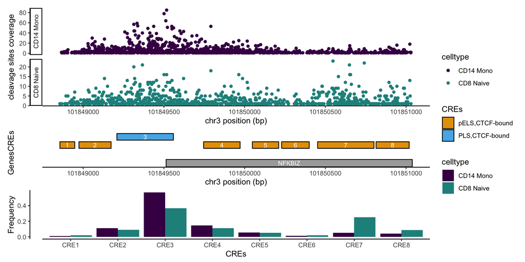

```r
Visualize(comparison1, which_peak = "chr3-101848856-101851038")
```

If you are interested in a specific peak, like the contribution of each CRE to the chi-square statistics, you can extract more details using the `Extract()` function.

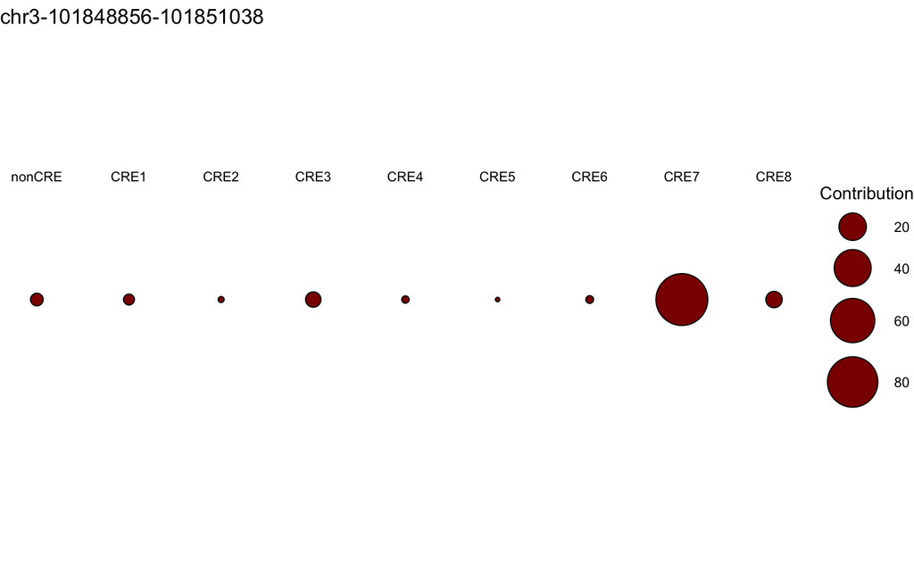

```r
info_for_a_peak <- Extract(comparison1, which_peak = "chr3-101848856-101851038")
info_for_a_peak$plot_contribution
```

```r
info_for_a_peak$annotation
```

```
##                          chisq_stat fdr max_contribution max_refID  max_dif
## chr3-101848856-101851038   2299.095   0         85.08247         1 0.813098
##                            abs_dif  n_1  n_2 df1
## chr3-101848856-101851038 0.1736074 6390 2590   9
##                                                                                                                                                CRE_type
## chr3-101848856-101851038 pELS,CTCF-bound;pELS,CTCF-bound;PLS,CTCF-bound;pELS,CTCF-bound;pELS,CTCF-bound;pELS,CTCF-bound;pELS,CTCF-bound;pELS,CTCF-bound
##                          seqnames     start       end width strand annotation
## chr3-101848856-101851038     chr3 101848856 101851038  2183      *   Promoter
##                          geneChr geneStart   geneEnd geneLength geneStrand
## chr3-101848856-101851038       3 101849514 101859523      10010          1
##                          geneId      transcriptId distanceToTSS         ENSEMBL
## chr3-101848856-101851038  64332 ENST00000326151.9             0 ENSG00000144802
##                          SYMBOL            GENENAME
## chr3-101848856-101851038 NFKBIZ NFKB inhibitor zeta
```

The following is a visualization of the CREscendo test results for a specific gene (CD55).

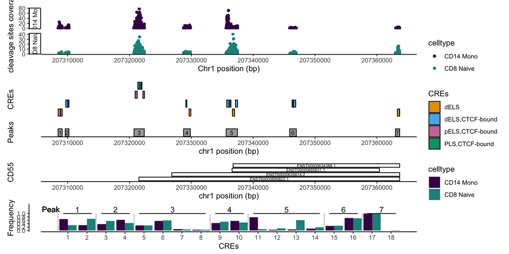

```r
Visualize(comparison1, which_gene = "CD55")
```

Similarly, more details can be extracted.

```r
info_for_a_gene <- Extract(comparison1, which_gene = "CD55")
info_for_a_gene$peak_annotation
```

```
##                           chisq_stat          fdr max_contribution max_refID
## chr1-207308445-207309112   27.857881 3.079820e-06         69.58541         1
## chr1-207309601-207310201   13.235005 3.160399e-03         62.38866         1
## chr1-207320718-207322383   35.805369 1.143515e-06         43.94907         1
## chr1-207328740-207329837    3.014726 3.124092e-01         50.82536         1
## chr1-207335620-207337449 7018.530052 0.000000e+00         71.71392         1
## chr1-207345894-207346966   10.809018 9.714787e-03         50.88519         1
## chr1-207362993-207363682    3.113853 2.604383e-01         49.21303         2
##                            max_dif    abs_dif  n_1  n_2 df1
## chr1-207308445-207309112 0.5490393 0.37028235  411   43   3
## chr1-207309601-207310201 0.3269231 0.16190476  306  105   3
## chr1-207320718-207322383 0.2343387 0.03147529 6864 3448   5
## chr1-207328740-207329837 0.1622679 0.03515003  674  259   3
## chr1-207335620-207337449 0.9271002 0.62898437 2774 2123   5
## chr1-207345894-207346966 0.3417468 0.16764937  159   96   3
## chr1-207362993-207363682 1.0000000 0.04676871   84  392   2
##                                                                               CRE_type
## chr1-207308445-207309112                                                     dELS;dELS
## chr1-207309601-207310201                               dELS,CTCF-bound;dELS,CTCF-bound
## chr1-207320718-207322383 pELS,CTCF-bound;PLS,CTCF-bound;PLS,CTCF-bound;pELS,CTCF-bound
## chr1-207328740-207329837                                          dELS,CTCF-bound;dELS
## chr1-207335620-207337449          dELS,CTCF-bound;dELS,CTCF-bound;dELS;dELS,CTCF-bound
## chr1-207345894-207346966                               dELS,CTCF-bound;dELS,CTCF-bound
## chr1-207362993-207363682                                                     dELS;dELS
##                          seqnames     start       end width strand
## chr1-207308445-207309112     chr1 207308445 207309112   668      *
## chr1-207309601-207310201     chr1 207309601 207310201   601      *
## chr1-207320718-207322383     chr1 207320718 207322383  1666      *
## chr1-207328740-207329837     chr1 207328740 207329837  1098      *
## chr1-207335620-207337449     chr1 207335620 207337449  1830      *
## chr1-207345894-207346966     chr1 207345894 207346966  1073      *
## chr1-207362993-207363682     chr1 207362993 207363682   690      *
##                                                                       annotation
## chr1-207308445-207309112 Exon (ENST00000634239.1/ENST00000634239.1, exon 4 of 4)
## chr1-207309601-207310201                                       Distal Intergenic
## chr1-207320718-207322383                                                Promoter
## chr1-207328740-207329837         Intron (ENST00000695822.1/1604, intron 5 of 10)
## chr1-207335620-207337449                                                Promoter
## chr1-207345894-207346966        Intron (ENST00000695822.1/1604, intron 10 of 10)
## chr1-207362993-207363682        Intron (ENST00000695822.1/1604, intron 10 of 10)
```

[output cut: 9 more lines]

```
## chr1-207308445-207309112   1604 ENST00000695822.1        -12407 ENSG00000196352
## chr1-207309601-207310201   1604 ENST00000695822.1        -11318 ENSG00000196352
## chr1-207320718-207322383   1604 ENST00000695822.1             0 ENSG00000196352
## chr1-207328740-207329837   1604 ENST00000635614.2          1908 ENSG00000196352
## chr1-207335620-207337449   1604 ENST00000695831.1             0 ENSG00000196352
## chr1-207345894-207346966   1604 ENST00000634386.1          9140 ENSG00000196352
## chr1-207362993-207363682   1604 ENST00000634386.1         26239 ENSG00000196352
##                          SYMBOL                           GENENAME
## chr1-207308445-207309112   CD55 CD55 molecule (Cromer blood group)
## chr1-207309601-207310201   CD55 CD55 molecule (Cromer blood group)
## chr1-207320718-207322383   CD55 CD55 molecule (Cromer blood group)
## chr1-207328740-207329837   CD55 CD55 molecule (Cromer blood group)
## chr1-207335620-207337449   CD55 CD55 molecule (Cromer blood group)
## chr1-207345894-207346966   CD55 CD55 molecule (Cromer blood group)
## chr1-207362993-207363682   CD55 CD55 molecule (Cromer blood group)
```

## Comparing with differential accessbility analysis

```r
DefaultAssay(pbmc) <- 'peaks'
tic()
da_peaks <- FindMarkers(
  object = pbmc,
  ident.1 = "CD14 Mono",
  ident.2 = "CD8 Naive",
  test.use = 'LR',
  latent.vars = 'nCount_peaks'
)
head(da_peaks)
```

```
##                           p_val avg_log2FC pct.1 pct.2 p_val_adj
## chr1-59814050-59815531        0  -3.431790 0.054 0.551         0
## chr12-10554105-10555474       0  -4.940126 0.016 0.485         0
## chr12-119988391-119990393     0  -3.096959 0.079 0.613         0
## chr13-74132877-74136577       0  -2.947274 0.128 0.755         0
## chr14-99603351-99605612       0  -2.790923 0.104 0.628         0
## chr15-75042681-75044045       0   5.731529 0.581 0.015         0
```

```r
toc()
```

```
## 1903.924 sec elapsed
```

We further compared the results from CREscendo and DA tests.

```r
chisq_test_summary <- Summarize(comparison1)
commons <- intersect(rownames(chisq_test_summary), rownames(da_peaks))
all_stats <- cbind(chisq_test_summary[commons, ], da_peaks[commons, ])


# Updated ggplot2 code with ggrepel for non-overlapping text labels
dq <- ggplot(all_stats, aes(x = avg_log2FC, y = chisq_stat)) +
  geom_point( size = 0.8) +
  geom_text_repel(data = subset(all_stats, chisq_stat > 2500),
                  aes(label = SYMBOL),
                  max.overlaps = Inf,
                  box.padding = 0.5,
                  point.padding = 0.5,
                  size = 3,  color = 'darkred') +
  xlim(-6, 6) +  # Slightly wider x-axis limits
  ylim(min(all_stats$chisq_stat), max(all_stats$chisq_stat) + 500) +  # Extend y-axis if necessary
  theme_classic() + labs(title = "CD14 Mono vs. CD8 Naive", x = "Avg log2FC", y = "Chi-square statistics") +
  theme(plot.margin = margin(1, 1, 1, 1, "cm"))  # Set x-axis limits
```

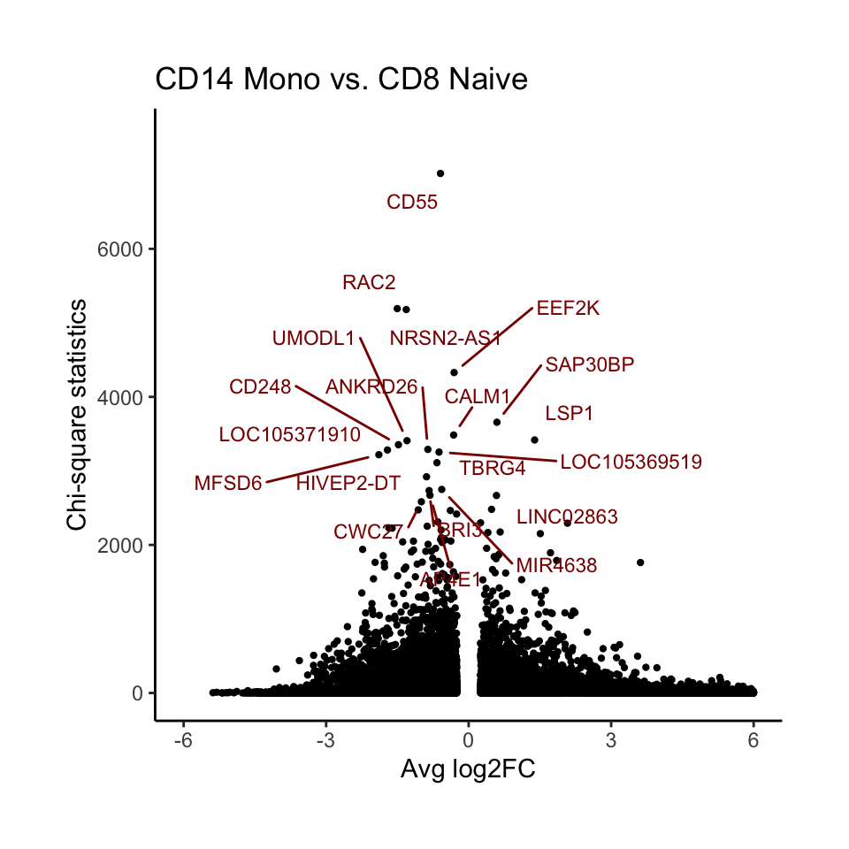

```r
dq
```